# Omy_Klamath_STRUCTURE

Kevin Olsen

2024-11-20

```r
library(kableExtra)
library(gt)
library(gtsummary)
library(knitr)
library(khroma)
library(adegenet)
library(magrittr)
library(tidyverse)
library(splitstackshape)
library(ggplot2)
```

Load quality filtered, location adjusted, and HWE/LD thinned markerset.

```r
load("C:/Users/olsenk2/OneDrive - Oregon State University/Desktop/Omy_klamath/Jan_2024_analyses/reproducible/Omykiss_Klamath_fullmarkerset_corrected_locations_Jan_2024_genos.R")
```

Revert the Omy-5 marker names to their original names (i.e., remove “Pearse” from the marker names). In the past, I’ve used base R to do this. Let’s use a tidyverse solution using the rename command from dplyr.

```r
full_markerset %<>%
  dplyr::rename(OmyR14589 = OmyR14589Pearse, OmyR19198 = OmyR19198Pearse, OmyR24370 = OmyR24370Pearse, OmyR33562 = OmyR33562Pearse, OmyR40252 = OmyR40252Pearse, OmyR40319 = OmyR40319Pearse)
```

Read in the metadata about markers. Filter the metadata to the markers that passed filtering.

```r
marker_mapping <- readxl::read_xlsx("C:/Users/olsenk2/OneDrive - Oregon State University/Desktop/Omykiss_Siletz_2023/Omy_GTseq_panel/final_mapping_results.xlsx", sheet = 1)

##filter mapping file to filtered markers in current panel##
marker_summary <- marker_mapping %>%
  mutate(marker = str_replace(marker, "Omy(\\d+)", "Chr\\1")) %>% # convert names to match
  filter(marker %in% colnames(full_markerset)) %>% # exclude filtered loci
  mutate(neutral = if_else(str_detect(`Presumed Type`, 'neutral|Neutral'), "neutral", "adaptive")) %>%
  mutate(run_timing = if_else(str_detect(`Presumed Type`, 'run|Run'), "run_timing", "non-run_timing")) %>%
  dplyr::select(marker, chr, start, 'Presumed Type', neutral, run_timing, Source)
```

Subset the neutral markers (n = 193 neutral markers).

```r
neutral_marker_list<-subset(marker_summary, marker_summary$neutral == "neutral")

##neutral markerset with adjusted locations##
neutral_markerset<-full_markerset[, c(1:27, which(colnames(full_markerset) %in% neutral_marker_list$marker))]  ##include sampling meta data in columns 1:27##
```

Subset the contemporary samples collected in the years 2015 - 2019.

```r
##Filter samples collected in the years 2000, 2003, and 2006
contemp_neutral_markerset <- neutral_markerset %>%
  filter(! c(Year_Collected == "2000" | Year_Collected == "2003" | Year_Collected == "2006"))
```

STRUCTURE uses numbers for location names. Add a column of numeric values for the pooled contemporary sampling locations. Note, n = 61 sampling events from n = 60 unique locations (Spring Creek in the Williamson River was sampled in the Fall and Summer).

```r
contemp_neutral_markerset %<>%
  mutate(site_number = case_when(Location %in% c('Hayfork Creek', 'Dubakella Creek') ~ '1',
                                   Location %in% c('Salt Creek', 'Philpot Creek') ~ '2',
                                   Location %in% c('East Fork Hayfork Creek') ~ '3',
                                   Location %in% c('Potato Creek') ~ '4',
                                   Location %in% c('Rusch Creek') ~ '5',
                                   Location %in% c('Eltapom Creek', 'South Fork Trinity River below Hyampom Creek') ~ '6',
                                   Location %in% c('CDFW Junction City Weir') ~ '7',
                                   Location %in% c('Grouse Creek') ~ '8',
                                   Location %in% c('Underwood Creek') ~ '9',
                                   Location %in% c('Mosquito Creek') ~ '10',
                                   Location %in% c('Blind Horse Creek', 'South Fork Salmon River above Blind Horse Creek') ~ '11',
                                   Location %in% c('Rush Creek', 'South Fork Salmon River above Rush Creek') ~ '12',
                                   Location %in% c('Garden Gulch', 'Rays Gulch') ~ '13',
                                   Location %in% c('St Claire Creek') ~ '14',
                                   Location %in% c('Plummer Creek', 'SF Salmon River below Plummer Creek') ~ '15',
                                   Location %in% c('Black Bear Creek') ~ '16',
                                   Location %in% c('Methodist Creek', 'Indian Creek') ~ '17',
                                   Location %in% c('Knownothing Creek', 'McNeal Creek') ~ '18',
                                   Location %in% c('Taylor Creek', 'Shadow Creek') ~ '19',
                                   Location %in% c('Shasta River') ~ '20',
                                   Location %in% c('Bogus Creek') ~ '21',
                                   Location %in% c('Lower Jenny Creek') ~ '22',
                                   Location %in% c('Upper Jenny Creek') ~ '23',
                                   Location %in% c('Beaver Creek') ~ '24',
                                   Location %in% c('Cold Creek') ~ '25',
                                   Location %in% c('Shovel Creek') ~ '26',
                                   Location %in% c('Peaking Reach') ~ '28',
                                   Location %in% c('Bypass Reach') ~ '27',
                                   Location %in% c('Keno Reach', 'Keno Reach Powerlines', 'Keno Dam') ~ '29',
                                   Location %in% c('Lower Spencer Creek') ~ '30',
                                   Location %in% c('Upper Spencer Creek') ~ '30',
                                   Location %in% c('Eagle Ridge', 'Harriman Creek', 'Howard Bay', 'Shoalwater Bay', 'Shoalwater Marsh', 'Shoalwater/Eagle Ridge', 'Skillet Handle') ~ '31',
                                   Location %in% c('Denny Creek') ~ '32',
                                   Location %in% c('Moss Creek') ~ '33',
                                   Location %in% c('Cherry Creek') ~ '34',
                                   Location %in% c('Sevenmile Creek') ~ '35',
                                   Location %in% c('Agency Creek') ~ '36',
                                   Location %in% c('Tecumseh Creek') ~ '37',
                                   Location %in% c('Fort Creek') ~ '38',
                                   Location %in% c('Upper Wood River') ~ '39',
                                   Location %in% c('Upper Annie Creek', 'Lower Annie Creek') ~ '40',
                                   Location %in% c('Pine Ridge') ~ '43',
                                   Location %in% c('Spring Creek Fall  Season') ~ '44',
                                   Location %in% c('Spring Creek Summer Season') ~ '45',
                                   Location %in% c('Sunnybrook Creek') ~ '46',
                                   Location %in% c('Knapps Dam','Kirk Spring') ~ '47',
                                   Location %in% c('Upper Williamson River') ~ '48',
                                   Location %in% c('South Fork Trout Creek') ~ '49',
                                   Location %in% c('Rock Creek') ~ '50',
                                   Location %in% c('Beatty Gap', 'Spring Creek_SPRR') ~ '51',
                                   Location %in% c('Paradise Creek_Sycan') ~ '52',
                                   Location %in% c('Paradise Creek_SF_Sprague') ~ '53',
                                   Location %in% c('Long Creek') ~ '54',
                                   Location %in% c('Fivemile Creek') ~ '55',
                                   Location %in% c('Meryl Creek') ~ '56',
                                   Location %in% c('Lower North Fork Sprague River', 'Upper North Fork Sprague River') ~ '57',
                                   Location %in% c('Whitworth Creek') ~ '58',
                                   Location %in% c('Upper South Fork Sprague River') ~ '59',
                                   Location %in% c('Kamkaun Spring') ~ '60',
                                   Location %in% c('Oak Springs Stock (53)') ~ '61',
                                   Location %in% c('Foster Creek') ~ '62',
                                   Location %in% c('Jones Crossing', 'Coffeepot Flat') ~ '63',
  ))

##put rows in order of location number##
contemp_neutral_markerset<-contemp_neutral_markerset[order(as.numeric(as.character(contemp_neutral_markerset$site_number))), ]
```

Format genotypes for STRUCTURE.

```r
##Subset matrix with sample names, site number, and genotype data##
gtypes<-contemp_neutral_markerset[, c(2, 221, 28:220)]

##add / delimiter to genotypes in order to split columns for STRUCTURE##
geno_cols<-colnames(gtypes)[3:195]

delim_gtypes <- as.data.frame(gtypes) %>%   ##Exclude columns 1 and 2 with sample names and location number
  mutate(across(geno_cols,
                ~ case_when(. == "AA" ~ "A/A",
                            . == "AT" ~ "A/T",
                            . == "AC" ~ "A/C",
                            . == "AG" ~ "A/G",
                            . == "TT" ~ "T/T",
                            . == "TA" ~ "T/A",
                            . == "TC" ~ "T/C",
                            . == "TG" ~ "T/G",
                            . == "CC" ~ "C/C",
                            . == "CA" ~ "C/A",
                            . == "CT" ~ "C/T",
                            . == "CG" ~ "C/G",
                            . == "GG" ~ "G/G",
                            . == "GA" ~ "G/A",
                            . == "GT" ~ "G/T",
                            . == "GC" ~ "G/C",
                            . == "--" ~ "-/-",
                            . == "A-" ~ "A/-",
                            . == "T-" ~ "T/-",
                            . == "C-" ~ "C/-",
                            . == "G-" ~ "G/-",
                            . == "-A" ~ "-/A",
                            . == "-T" ~ "-/T",
                            . == "-C" ~ "-/C",
                            . == "-G" ~ "-/G",
                            . == "00" ~ "0/0",
                            . == "0" ~ "0/0"
  )))

##Split genotypes into two columns for STRUCTURE##
split_gtypes<-cSplit(delim_gtypes, sep = "/", splitCols = geno_cols, type.convert = FALSE)

##replace nucleotides with numeric values for STRUCTURE##
##Note missing data = -9 in STRUCTURE##
##A = 1; T = 2; C = 3; G = 4; - = 5 ###
geno_cols<-colnames(split_gtypes)[3:ncol(split_gtypes)]

split_gtypes %<>%
  mutate(across(geno_cols,
                ~ case_when(. == "A" ~ 1,
                            . == "T" ~ 2,
                            . == "C" ~ 3,
                            . == "G" ~ 4,
                            . == "-" ~ 5,
                            . == "0" ~ -9,
  )))
```

Write this dataframe for the input file for STRUCTURE.

```r
##write text file for input to STRUCTURE##
write.table(split_gtypes, quote = FALSE, sep = "\t", row.names = FALSE, col.names = FALSE,
            file = "C:/Users/olsenk2/OneDrive - Oregon State University/Desktop/Omy_klamath/Jan_2024_analyses/reproducible/Omykiss_Klamath_Neutral_adjusted_locations_STRUCTURE_input.txt")
```

Genetic variation among contemporary collections was assessed in the neutral dataset with STRUCTURE using an admixture model, correlated allele frequency, a burn-in of 10,000 iterations, run length of 20,000 iterations, and 10 replicates for k = 1 to k = 11. Results from replicated runs of each k were combined using CLUMPAK (Kopelman et al. 2015). We estimated the best supported k with Δk and the mean log probability, and we found k = 2 to be the best supported number of k clusters.

Read in clumpacked STRUCTURE results with k = 2 clusters.

```r
st_results<-read.csv("C:/Users/olsenk2/OneDrive - Oregon State University/Desktop/Omy_klamath/Jan_2024_analyses/reproducible/CLUMPAK_output/K=2/MajorCluster/CLUMPP.files/ClumppIndFile.csv", header = FALSE)
```

STRUCTURE output has numeric values instead of sample names. These values come from the row numbers in the STRUCTURE input file. Use the row numbers to add sampling location metadata into STRUCTURE results.

```r
##make a column with the row number for each sample in the genotype dataframe
contemp_neutral_markerset %<>%
  rownames_to_column("str_Ind")

contemp_neutral_markerset$str_Ind<-as.numeric(contemp_neutral_markerset$str_Ind)

##Add sample metadata and sampling information to STRUCTURE results
st_results %<>%
  left_join(select(contemp_neutral_markerset, sample_simple, basin, Location, location_code, site_number, str_Ind), by = c("V1" = "str_Ind"))

st_results %<>%
  relocate(sample_simple, basin, Location, location_code, site_number, V1, V2, V3, V4) %>%
  dplyr::rename(Ind = sample_simple, Basin = basin, samp_location = Location, str_Ind = V1, Pop = V2, k1 = V3, k2 = V4)

##Pivot longer for bar plot in ggplot2
st_results %<>%
  pivot_longer(cols = c(k1, k2))

kable(st_results[1:20, ])
```

| Ind | Basin | samp_location | location_code | site_number | str_Ind | Pop | name | value |
| --- | --- | --- | --- | --- | --- | --- | --- | --- |
| OmyJC16TRIR_0008 | LKB | Hayfork Creek | HAYF | 1 | 1 | 1 | k1 | 0.9533 |
| OmyJC16TRIR_0008 | LKB | Hayfork Creek | HAYF | 1 | 1 | 1 | k2 | 0.0467 |
| OmyJC16TRIR_0012 | LKB | Hayfork Creek | HAYF | 1 | 2 | 1 | k1 | 0.9647 |
| OmyJC16TRIR_0012 | LKB | Hayfork Creek | HAYF | 1 | 2 | 1 | k2 | 0.0353 |
| OmyJC16TRIR_0013 | LKB | Hayfork Creek | HAYF | 1 | 3 | 1 | k1 | 0.9848 |
| OmyJC16TRIR_0013 | LKB | Hayfork Creek | HAYF | 1 | 3 | 1 | k2 | 0.0152 |
| OmyJC16TRIR_0018 | LKB | Hayfork Creek | HAYF | 1 | 4 | 1 | k1 | 0.9502 |
| OmyJC16TRIR_0018 | LKB | Hayfork Creek | HAYF | 1 | 4 | 1 | k2 | 0.0498 |
| OmyJC16TRIR_0021 | LKB | Hayfork Creek | HAYF | 1 | 5 | 1 | k1 | 0.9355 |
| OmyJC16TRIR_0021 | LKB | Hayfork Creek | HAYF | 1 | 5 | 1 | k2 | 0.0645 |
| OmyJC16TRIR_0028 | LKB | Hayfork Creek | HAYF | 1 | 6 | 1 | k1 | 0.9370 |
| OmyJC16TRIR_0028 | LKB | Hayfork Creek | HAYF | 1 | 6 | 1 | k2 | 0.0630 |
| OmyJC16TRIR_0030 | LKB | Hayfork Creek | HAYF | 1 | 7 | 1 | k1 | 0.9855 |
| OmyJC16TRIR_0030 | LKB | Hayfork Creek | HAYF | 1 | 7 | 1 | k2 | 0.0145 |
| OmyJC16TRIR_0031 | LKB | Hayfork Creek | HAYF | 1 | 8 | 1 | k1 | 0.9787 |
| OmyJC16TRIR_0031 | LKB | Hayfork Creek | HAYF | 1 | 8 | 1 | k2 | 0.0213 |
| OmyJC16TRIR_0032 | LKB | Hayfork Creek | HAYF | 1 | 9 | 1 | k1 | 0.9271 |
| OmyJC16TRIR_0032 | LKB | Hayfork Creek | HAYF | 1 | 9 | 1 | k2 | 0.0729 |
| OmyJC16TRIR_0046 | LKB | Dubakella Creek | HAYF | 1 | 10 | 1 | k1 | 0.9739 |
| OmyJC16TRIR_0046 | LKB | Dubakella Creek | HAYF | 1 | 10 | 1 | k2 | 0.0261 |

Add watershed names to STRUCTURE results. Set order of watersheds, locations within watersheds, and individuals within locations.

```r
all_basin <- st_results %>%
  mutate(watershed = case_when(Pop <= 10 ~ 'Trinity River',
                               Pop <= 19 ~ 'Salmon River',
                               Pop <= 21 ~ 'Lower Klamath River',
                               Pop <= 30 ~ 'Klamath River',
                               Pop <= 31 ~ 'Upper Klamath Lake',
                               Pop <= 35 ~ 'KLCT',
                               Pop <= 40 ~ 'Wood River',
                               Pop <= 42 ~ 'Wood River',
                               Pop <= 48 ~ 'Williamson River',
                               Pop <= 60 ~ 'Sprague River',
                               Pop <= 61 ~ 'Klamath Hatchery',
                               Pop <= 63 ~ 'Great Basin'
  ))
##set order of locations / individuals##
all_basin %<>%
  mutate(structure_number = case_when(location_code %in% c('HAYF') ~ '10',
                                     location_code %in% c('SALT') ~ '7',
                                     location_code %in% c('EFHF') ~ '8',
                                     location_code %in% c('POTA') ~ '9',
                                     location_code %in% c('RSCH') ~ '6',
                                     location_code %in% c('ELTP') ~ '5',
                                     location_code %in% c('JCNW') ~ '1',
                                     location_code %in% c('GROU') ~ '3',
                                     location_code %in% c('UDWD') ~ '4',
                                     location_code %in% c('MOSQ') ~ '2',
                                     location_code %in% c('HORS') ~ '18',
                                     location_code %in% c('RUSH') ~ '19',
                                     location_code %in% c('GARD') ~ '17',
                                     location_code %in% c('CLAR') ~ '15',
                                     location_code %in% c('PLUM') ~ '14',
                                     location_code %in% c('BKBR') ~ '13',
                                     location_code %in% c('METH_03') ~ '12',
                                     location_code %in% c('METH') ~ '12',
                                     location_code %in% c('KNOW') ~ '11',
                                     location_code %in% c('TAYL') ~ '16',
                                     location_code %in% c('SHAS') ~ '20',
                                     location_code %in% c('BOGS') ~ '21',
                                     location_code %in% c('LJNY') ~ '22',
                                     location_code %in% c('UJNY_00') ~ '23',
                                     location_code %in% c('UJNY') ~ '23',
                                     location_code %in% c('BEAV') ~ '24',
                                     location_code %in% c('COLD') ~ '25',
                                     location_code %in% c('SHOV') ~ '26',
                                     location_code %in% c('BYPR_00') ~ '28',
                                     location_code %in% c('BYPR') ~ '28',
                                     location_code %in% c('PEAR') ~ '27',
                                     location_code %in% c('KENO_00') ~ '29',
                                     location_code %in% c('KENO') ~ '29',
                                     location_code %in% c('SPCR_00') ~ '30',
                                     location_code %in% c('SPCR') ~ '30',
                                     location_code %in% c('UKLA') ~ '31',
                                     location_code %in% c('DENN') ~ '32',
                                     location_code %in% c('MOSS') ~ '33',
                                     location_code %in% c('CHER_00') ~ '34',
                                     location_code %in% c('CHER') ~ '34',
                                     location_code %in% c('SEVN') ~ '35',
                                     location_code %in% c('AGNC') ~ '36',
                                     location_code %in% c('TECH') ~ '37',
                                     location_code %in% c('FORT') ~ '38',
                                     location_code %in% c('WOOD') ~ '39',
                                     location_code %in% c('ANNI') ~ '40',
                                     location_code %in% c('PINE') ~ '41',
                                     location_code %in% c('SCFA') ~ '42',
                                     location_code %in% c('SCSU_00') ~ '43',
                                     location_code %in% c('SCSU') ~ '43',
                                     location_code %in% c('SUNY') ~ '44',
                                     location_code %in% c('KNAP') ~ '45',
                                     location_code %in% c('UWIL') ~ '46',
                                     location_code %in% c('SFTC_00') ~ '49',
                                     location_code %in% c('SFTC') ~ '49',
                                     location_code %in% c('ROKS_00') ~ '50',
                                     location_code %in% c('ROKS') ~ '50',
                                     location_code %in% c('BTTY') ~ '48',
                                     location_code %in% c('PASY_00') ~ '52',
                                     location_code %in% c('PASY') ~ '52',
                                     location_code %in% c('LONG_00') ~ '51',
                                     location_code %in% c('LONG') ~ '51',
                                     location_code %in% c('FIVE_00') ~ '53',
                                     location_code %in% c('FIVE') ~ '53',
                                     location_code %in% c('MRYL') ~ '54',
                                     location_code %in% c('NFSP_06') ~ '55',
                                     location_code %in% c('NFSP') ~ '55',
                                     location_code %in% c('PASP') ~ '56',
                                     location_code %in% c('WHIT') ~ '57',
                                     location_code %in% c('SFSP') ~ '58',
                                     location_code %in% c('KAMK') ~ '47',
                                     location_code %in% c('CHEW') ~ '59',
                                     location_code %in% c('FOST') ~ '60',
                                     location_code %in% c('OAKH') ~ '61'
  ))

##put rows in order of location number##
all_basin<-all_basin[order(as.numeric(as.character(all_basin$structure_number)), all_basin$str_Ind), ]

##set order of watersheds##
all_basin$watershed <- factor(all_basin$watershed, levels = unique(all_basin$watershed))

##set order of locations##
all_basin$structure_number<-factor(all_basin$structure_number, levels = unique(all_basin$structure_number))

##set order of individuals##
all_basin$str_Ind<-factor(all_basin$str_Ind, levels = unique(all_basin$str_Ind))
```

Calculate vertical line placement for locations based on their sample size.

```r
df_segment_all_locations <- all_basin %>%
  group_by(structure_number) %>%
  summarise(n = sum(length(unique(Ind))))

##vertical lines delineating locations##
##Add the sample size of the current location to the one before it with the cumulative sum (cumsum) command##
vlines<-cumsum(as.numeric(df_segment_all_locations$n))
```

Make the STRUCTURE plot for all watersheds (Fig. 2a ; k = 2). Note, the plot created in this R markdown file is compressed. Export the plot to make it larger.

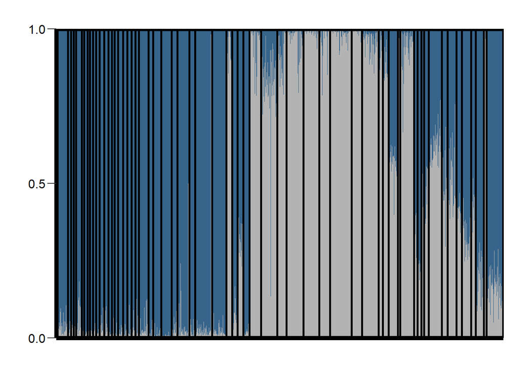

```r
ggplot(all_basin, aes(fill = name, y = value, x = str_Ind)) +
  geom_bar(position = "stack", stat = "identity", width = 1) +
  scale_fill_manual(values = c("steelblue4", "grey70"), name = "Cluster") +
  geom_segment(aes(x = 0.5, xend = 2081.5, y = 1.0, yend = 1.0), colour = 'black', linewidth = 2, inherit.aes = FALSE) +
  scale_x_discrete(expand = c(0.0, 0.0)) +
  scale_y_continuous(expand = c(0, 0), breaks = c(0.0, 0.5, 1.0)) +
  geom_line() +
  geom_vline(xintercept = vlines, linewidth = 1)+
  xlab("") +
  ylab("") +
  theme(panel.background = element_blank(),
        text = element_text(family = "sans"),
        legend.position = "none",
        plot.margin = margin(1, 0.5, 0.5, 0.5, "cm"),
        legend.title = element_text(size = 16),
        legend.text = element_text(size = 12),
        axis.line = element_line(size = 2, color = 'black'),
        axis.ticks.x = element_blank(),
        axis.ticks.length.y = unit(0.3, "cm"),
        axis.text.x = element_blank(),
        axis.text.y = element_text(size = 12, colour = 'black')
  )
```

Prepare STRUCTURE results for only those locations downstream of the Upper Klamath Lake.

```r
##Subset locations downstream of Upper Klamath Lake
below<-subset(all_basin, all_basin$watershed == "Trinity River" | all_basin$watershed == "Salmon River" | all_basin$watershed == "Lower Klamath River" | all_basin$watershed == "Klamath River")

##New object so need to reset order of individuals within locations, locations within watersheds, and watersheds
below$str_Ind<-factor(below$str_Ind, levels = unique(below$str_Ind))
below$structure_number<-factor(below$structure_number, levels = unique(below$structure_number))
below$watershed <- factor(below$watershed, levels = unique(below$watershed))

##Calculate vertical line placement for each location based on their sample size
df_segment_below <- below %>%
  group_by(structure_number) %>%
  summarise(n = sum(length(unique(Ind))))

##Add the sample size of the current location to the one before it with the cumulative sum (cumsum) command##
vlines<-cumsum(as.numeric(df_segment_below$n))
```

Make the STRUCTURE plot for those watersheds downstream of the Upper Klamath Lake (Fig. 2b ; k = 2). Note, the plot created in this R markdown file is compressed. Export the plot to make it larger.

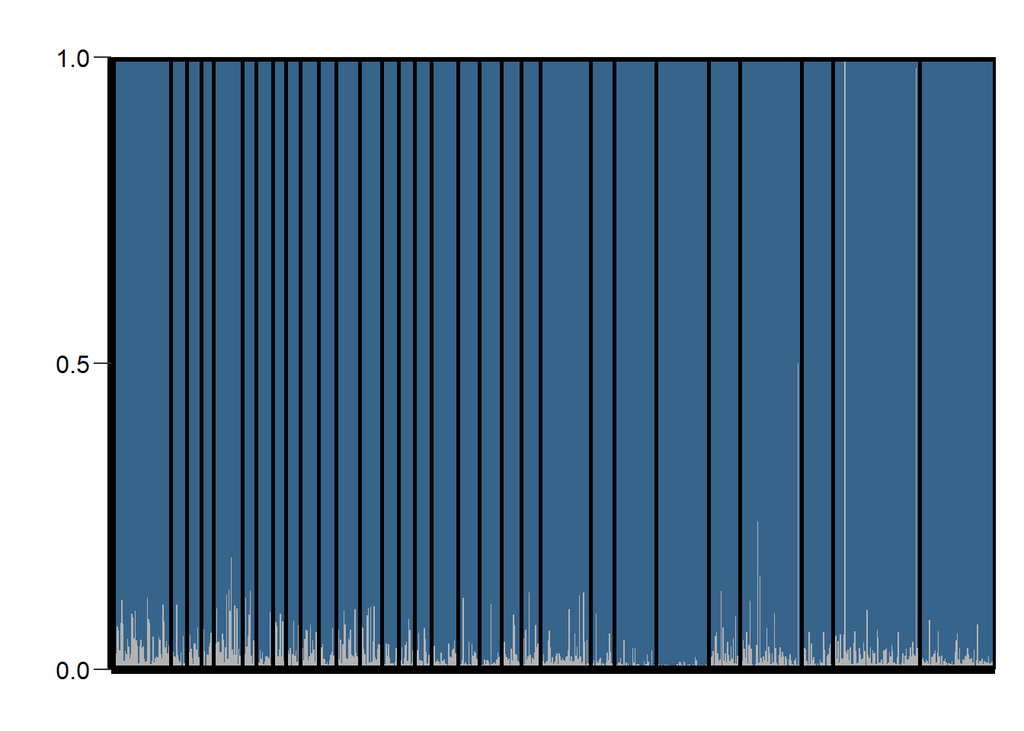

```r
ggplot(below, aes(fill = name, y = value, x = str_Ind)) +
  geom_bar(position = "stack", stat = "identity", width = 1) +
  scale_fill_manual(values = c("steelblue4", "grey70"), name = "Cluster") +
  geom_segment(aes(x = 0.5, xend = 792.5, y = 1.0, yend = 1.0), colour = 'black', linewidth = 2, inherit.aes = FALSE) +
  scale_x_discrete(expand = c(0.0, 0.0)) +
  scale_y_continuous(expand = c(0, 0), breaks = c(0.0, 0.5, 1.0)) +
  geom_line() +
  geom_vline(xintercept = vlines, linewidth = 1)+
  xlab("") +
  ylab("") +
  theme(panel.background = element_blank(),
        text = element_text(family = "sans"),
        legend.position = "none",
        plot.margin = margin(1, 0.5, 0.5, 0.5, "cm"),
        legend.title = element_text(size = 16),
        legend.text = element_text(size = 12),
        axis.line = element_line(size = 2, color = 'black'),
        axis.ticks.x = element_blank(),
        axis.ticks.length.y = unit(0.3, "cm"),
        axis.text.x = element_blank(),
        axis.text.y = element_text(size = 12, colour = 'black')
  )
```

Prepare STRUCTURE results for the Upper Klamath Lake and those watersheds upstream.

```r
##Subset locations upstream of Upper Klamath Lake
upper<-subset(all_basin, all_basin$watershed == "Upper Klamath Lake" | all_basin$watershed == "KLCT" | all_basin$watershed == "Wood River" | all_basin$watershed == "Williamson River" | all_basin$watershed == "Sprague River" | all_basin$watershed == "Great Basin" | all_basin$watershed == "Cape Cod Stock (72)" | all_basin$watershed == "Klamath Hatchery")

##New object so need to reset order of individuals within locations, locations within watersheds, and watersheds
upper$structure_number <- factor(upper$structure_number, levels = unique(upper$structure_number))
upper$str_Ind<-factor(upper$str_Ind, levels = unique(upper$str_Ind))
upper$watershed <- factor(upper$watershed, levels = unique(upper$watershed))

####Calculate vertical line placement for each location based on their sample size
df_segment_upper <- upper %>%
  group_by(structure_number) %>%
  summarise(n = sum(length(unique(Ind))))

##Add the sample size of the current location to the one before it with the cumulative sum (cumsum) command##
vlines<-cumsum(as.numeric(df_segment_upper$n))
```

Make the STRUCTURE plot for the Upper Klamath Lake and those watersheds upstream (Fig. 2c ; k = 2). Note, the plot created in this R markdown file is compressed. Export the plot to make it larger.

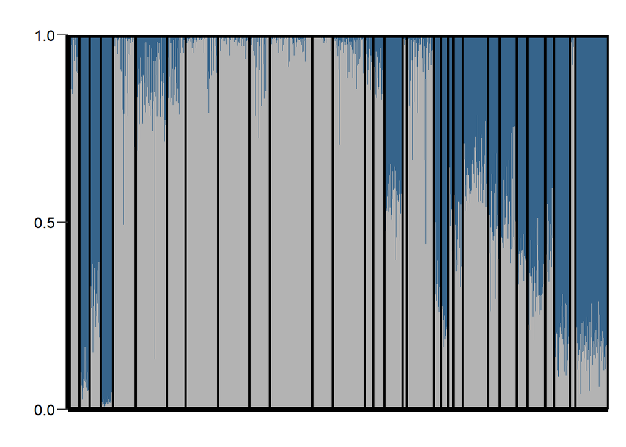

```r
ggplot(upper, aes(fill = name, y = value, x = str_Ind)) +
  geom_bar(position = "stack", stat = "identity", width = 1) +
  scale_fill_manual(values = c("steelblue4", "grey70"), name = "Cluster") +
  geom_segment(aes(x = 0.5, xend = 1289.5, y = 1.0, yend = 1.0), colour = 'black', linewidth = 2, inherit.aes = FALSE) +
  scale_x_discrete(expand = c(0.0, 0.0)) +
  scale_y_continuous(expand = c(0, 0), breaks = c(0.0, 0.5, 1.0)) +
  geom_line() +
  geom_vline(xintercept = vlines, linewidth = 1)+
  xlab("") +
  ylab("") +
  theme(panel.background = element_blank(),
        text = element_text(family = "sans"),
        legend.position = "none",
        plot.margin = margin(1, 0.5, 0.5, 0.5, "cm"),
        legend.title = element_text(size = 16),
        legend.text = element_text(size = 12),
        axis.line = element_line(size = 2, color = 'black'),
        axis.ticks.x = element_blank(),
        axis.ticks.length.y = unit(0.3, "cm"),
        axis.text.x = element_blank(),
        axis.text.y = element_text(size = 12, colour = 'black')
  )
```

Now we will the generate the corresponding STRUCTURE plots with k = 4 clusters. Note, these results get generated to an entirely distinct output. So, the formatting process needs to be repeated.

Read in clumpacked STRUCTURE results with k = 4 clusters.

```r
st_results<-read.csv("C:/Users/olsenk2/OneDrive - Oregon State University/Desktop/Omy_klamath/Jan_2024_analyses/reproducible/CLUMPAK_output/K=4/MajorCluster/CLUMPP.files/ClumppIndFile.csv", header = FALSE)
```

STRUCTURE output has numeric values instead of sample names. These values come from the row numbers in the STRUCTURE input file. Use the row numbers to add sampling location metadata into STRUCTURE results.

```r
##Add sample metadata and sampling information to STRUCTURE results
st_results %<>%
  left_join(select(contemp_neutral_markerset, sample_simple, basin, Location, location_code, site_number, str_Ind), by = c("V1" = "str_Ind"))

st_results %<>%
  relocate(sample_simple, basin, Location, location_code, site_number, V1, V2, V3, V4, V5, V6) %>%
  dplyr::rename(Ind = sample_simple, Basin = basin, samp_location = Location, str_Ind = V1, Pop = V2, k1 = V3, k2 = V4, k3 = V5, k4 = V6)

##Pivot longer for bar plot in ggplot2
st_results %<>%
  pivot_longer(cols = c(k1, k2, k3, k4))

kable(st_results[1:20, ])
```

| Ind | Basin | samp_location | location_code | site_number | str_Ind | Pop | name | value |
| --- | --- | --- | --- | --- | --- | --- | --- | --- |
| OmyJC16TRIR_0008 | LKB | Hayfork Creek | HAYF | 1 | 1 | 1 | k1 | 0.9261 |
| OmyJC16TRIR_0008 | LKB | Hayfork Creek | HAYF | 1 | 1 | 1 | k2 | 0.0191 |
| OmyJC16TRIR_0008 | LKB | Hayfork Creek | HAYF | 1 | 1 | 1 | k3 | 0.0209 |
| OmyJC16TRIR_0008 | LKB | Hayfork Creek | HAYF | 1 | 1 | 1 | k4 | 0.0339 |
| OmyJC16TRIR_0012 | LKB | Hayfork Creek | HAYF | 1 | 2 | 1 | k1 | 0.9381 |
| OmyJC16TRIR_0012 | LKB | Hayfork Creek | HAYF | 1 | 2 | 1 | k2 | 0.0183 |
| OmyJC16TRIR_0012 | LKB | Hayfork Creek | HAYF | 1 | 2 | 1 | k3 | 0.0220 |
| OmyJC16TRIR_0012 | LKB | Hayfork Creek | HAYF | 1 | 2 | 1 | k4 | 0.0216 |
| OmyJC16TRIR_0013 | LKB | Hayfork Creek | HAYF | 1 | 3 | 1 | k1 | 0.9394 |
| OmyJC16TRIR_0013 | LKB | Hayfork Creek | HAYF | 1 | 3 | 1 | k2 | 0.0079 |
| OmyJC16TRIR_0013 | LKB | Hayfork Creek | HAYF | 1 | 3 | 1 | k3 | 0.0436 |
| OmyJC16TRIR_0013 | LKB | Hayfork Creek | HAYF | 1 | 3 | 1 | k4 | 0.0091 |
| OmyJC16TRIR_0018 | LKB | Hayfork Creek | HAYF | 1 | 4 | 1 | k1 | 0.9337 |
| OmyJC16TRIR_0018 | LKB | Hayfork Creek | HAYF | 1 | 4 | 1 | k2 | 0.0271 |
| OmyJC16TRIR_0018 | LKB | Hayfork Creek | HAYF | 1 | 4 | 1 | k3 | 0.0113 |
| OmyJC16TRIR_0018 | LKB | Hayfork Creek | HAYF | 1 | 4 | 1 | k4 | 0.0278 |
| OmyJC16TRIR_0021 | LKB | Hayfork Creek | HAYF | 1 | 5 | 1 | k1 | 0.9107 |
| OmyJC16TRIR_0021 | LKB | Hayfork Creek | HAYF | 1 | 5 | 1 | k2 | 0.0274 |
| OmyJC16TRIR_0021 | LKB | Hayfork Creek | HAYF | 1 | 5 | 1 | k3 | 0.0210 |
| OmyJC16TRIR_0021 | LKB | Hayfork Creek | HAYF | 1 | 5 | 1 | k4 | 0.0409 |

Add watershed names to STRUCTURE results. Set order of watersheds, locations within watersheds, and individuals within locations.

```r
all_basin <- st_results %>%
  mutate(watershed = case_when(Pop <= 10 ~ 'Trinity River',
                               Pop <= 19 ~ 'Salmon River',
                               Pop <= 21 ~ 'Lower Klamath River',
                               Pop <= 30 ~ 'Klamath River',
                               Pop <= 31 ~ 'Upper Klamath Lake',
                               Pop <= 35 ~ 'KLCT',
                               Pop <= 40 ~ 'Wood River',
                               Pop <= 42 ~ 'Wood River',
                               Pop <= 48 ~ 'Williamson River',
                               Pop <= 60 ~ 'Sprague River',
                               Pop <= 61 ~ 'Klamath Hatchery',
                               Pop <= 63 ~ 'Great Basin'
  ))
##set order of locations / individuals##
all_basin %<>%
  mutate(structure_number = case_when(location_code %in% c('HAYF') ~ '10',
                                      location_code %in% c('SALT') ~ '7',
                                      location_code %in% c('EFHF') ~ '8',
                                      location_code %in% c('POTA') ~ '9',
                                      location_code %in% c('RSCH') ~ '6',
                                      location_code %in% c('ELTP') ~ '5',
                                      location_code %in% c('JCNW') ~ '1',
                                      location_code %in% c('GROU') ~ '3',
                                      location_code %in% c('UDWD') ~ '4',
                                      location_code %in% c('MOSQ') ~ '2',
                                      location_code %in% c('HORS') ~ '18',
                                      location_code %in% c('RUSH') ~ '19',
                                      location_code %in% c('GARD') ~ '17',
                                      location_code %in% c('CLAR') ~ '15',
                                      location_code %in% c('PLUM') ~ '14',
                                      location_code %in% c('BKBR') ~ '13',
                                      location_code %in% c('METH_03') ~ '12',
                                      location_code %in% c('METH') ~ '12',
                                      location_code %in% c('KNOW') ~ '11',
                                      location_code %in% c('TAYL') ~ '16',
                                      location_code %in% c('SHAS') ~ '20',
                                      location_code %in% c('BOGS') ~ '21',
                                      location_code %in% c('LJNY') ~ '22',
                                      location_code %in% c('UJNY_00') ~ '23',
                                      location_code %in% c('UJNY') ~ '23',
                                      location_code %in% c('BEAV') ~ '24',
                                      location_code %in% c('COLD') ~ '25',
                                      location_code %in% c('SHOV') ~ '26',
                                      location_code %in% c('BYPR_00') ~ '28',
                                      location_code %in% c('BYPR') ~ '28',
                                      location_code %in% c('PEAR') ~ '27',
                                      location_code %in% c('KENO_00') ~ '29',
                                      location_code %in% c('KENO') ~ '29',
                                      location_code %in% c('SPCR_00') ~ '30',
                                      location_code %in% c('SPCR') ~ '30',
                                      location_code %in% c('UKLA') ~ '31',
                                      location_code %in% c('DENN') ~ '32',
                                      location_code %in% c('MOSS') ~ '33',
                                      location_code %in% c('CHER_00') ~ '34',
                                      location_code %in% c('CHER') ~ '34',
                                      location_code %in% c('SEVN') ~ '35',
                                      location_code %in% c('AGNC') ~ '36',
                                      location_code %in% c('TECH') ~ '37',
                                      location_code %in% c('FORT') ~ '38',
                                      location_code %in% c('WOOD') ~ '39',
                                      location_code %in% c('ANNI') ~ '40',
                                      location_code %in% c('PINE') ~ '41',
                                      location_code %in% c('SCFA') ~ '42',
                                      location_code %in% c('SCSU_00') ~ '43',
                                      location_code %in% c('SCSU') ~ '43',
                                      location_code %in% c('SUNY') ~ '44',
                                      location_code %in% c('KNAP') ~ '45',
                                      location_code %in% c('UWIL') ~ '46',
                                      location_code %in% c('SFTC_00') ~ '49',
                                      location_code %in% c('SFTC') ~ '49',
                                      location_code %in% c('ROKS_00') ~ '50',
                                      location_code %in% c('ROKS') ~ '50',
                                      location_code %in% c('BTTY') ~ '48',
                                      location_code %in% c('PASY_00') ~ '52',
                                      location_code %in% c('PASY') ~ '52',
                                      location_code %in% c('LONG_00') ~ '51',
                                      location_code %in% c('LONG') ~ '51',
                                      location_code %in% c('FIVE_00') ~ '53',
                                      location_code %in% c('FIVE') ~ '53',
                                      location_code %in% c('MRYL') ~ '54',
                                      location_code %in% c('NFSP_06') ~ '55',
                                      location_code %in% c('NFSP') ~ '55',
                                      location_code %in% c('PASP') ~ '56',
                                      location_code %in% c('WHIT') ~ '57',
                                      location_code %in% c('SFSP') ~ '58',
                                      location_code %in% c('KAMK') ~ '47',
                                      location_code %in% c('CHEW') ~ '59',
                                      location_code %in% c('FOST') ~ '60',
                                      location_code %in% c('OAKH') ~ '61'
  ))
##put rows in order of location number##
all_basin<-all_basin[order(as.numeric(as.character(all_basin$structure_number)), all_basin$str_Ind), ]

##set order of watersheds##
all_basin$watershed <- factor(all_basin$watershed, levels = unique(all_basin$watershed))

##set order of locations##
all_basin$structure_number<-factor(all_basin$structure_number, levels = unique(all_basin$structure_number))

##set order of individuals##
all_basin$str_Ind<-factor(all_basin$str_Ind, levels = unique(all_basin$str_Ind))
```

Calculate vertical line placement for locations based on their sample size.

```r
df_segment_all_locations <- all_basin %>%
  group_by(structure_number) %>%
  summarise(n = sum(length(unique(Ind))))

##vertical lines delineating locations##
##Add the sample size of the current location to the one before it with the cumsum command##
vlines<-cumsum(as.numeric(df_segment_all_locations$n))
```

Make the STRUCTURE plot for all watersheds (Fig. 2a ; k = 4). Note, the plot created in this R markdown file is compressed. Export the plot to make it larger.

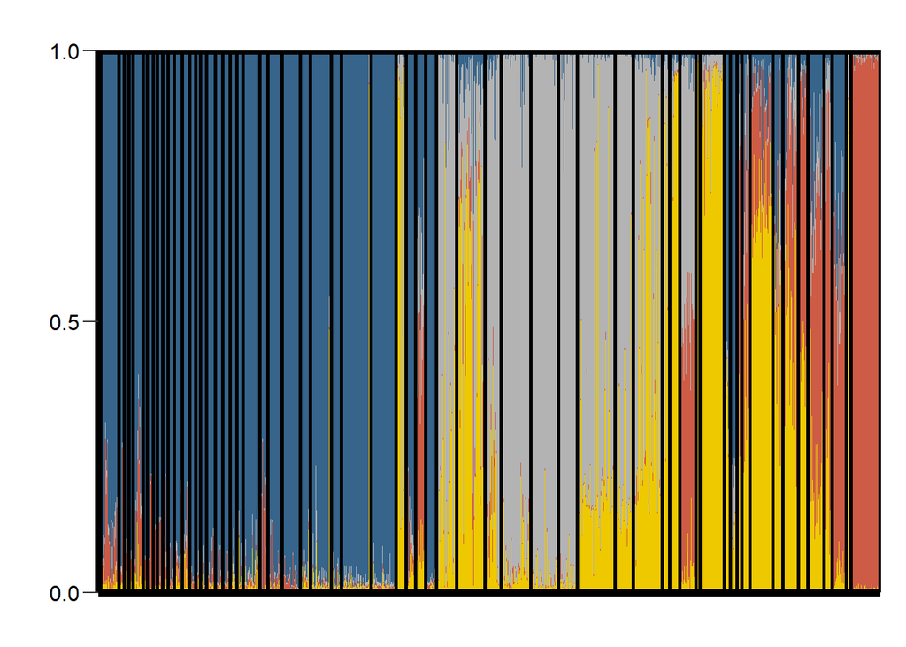

```r
ggplot(all_basin, aes(fill = name, y = value, x = str_Ind)) +
  geom_bar(position = "stack", stat = "identity", width = 1) +
  scale_fill_manual(values = c("steelblue4", "grey70", "coral3", "gold2"), name = "Cluster") +
  geom_segment(aes(x = 0.5, xend = 2081.5, y = 1.0, yend = 1.0), colour = 'black', linewidth = 2, inherit.aes = FALSE) +
  scale_x_discrete(expand = c(0.0, 0.0)) +
  scale_y_continuous(expand = c(0, 0), breaks = c(0.0, 0.5, 1.0)) +
  geom_line() +
  geom_vline(xintercept = vlines, linewidth = 1)+
  xlab("") +
  ylab("") +
  theme(panel.background = element_blank(),
        text = element_text(family = "sans"),
        legend.position = "none",
        plot.margin = margin(1, 0.5, 0.5, 0.5, "cm"),
        legend.title = element_text(size = 16),
        legend.text = element_text(size = 12),
        axis.line = element_line(size = 2, color = 'black'),
        axis.ticks.x = element_blank(),
        axis.ticks.length.y = unit(0.3, "cm"),
        axis.text.x = element_blank(),
        axis.text.y = element_text(size = 12, colour = 'black')
  )
```

Prepare STRUCTURE results for only those locations downstream of the Upper Klamath Lake.

```r
##Subset locations downstream of Upper Klamath Lake
below<-subset(all_basin, all_basin$watershed == "Trinity River" | all_basin$watershed == "Salmon River" | all_basin$watershed == "Lower Klamath River" | all_basin$watershed == "Klamath River")

##New object so need to reset order of individuals within locations, locations within watersheds, and watersheds
below$str_Ind<-factor(below$str_Ind, levels = unique(below$str_Ind))
below$structure_number<-factor(below$structure_number, levels = unique(below$structure_number))
below$watershed <- factor(below$watershed, levels = unique(below$watershed))

##Calculate vertical line placement for each location based on their sample size
df_segment_below <- below %>%
  group_by(structure_number) %>%
  summarise(n = sum(length(unique(Ind))))

##Add the sample size of the current location to the one before it with the cumulative sum (cumsum) command##
vlines<-cumsum(as.numeric(df_segment_below$n))
```

Make the STRUCTURE plot for those watersheds downstream of the Upper Klamath Lake (Fig. 2b ; k = 4). Note, the plot created in this R markdown file is compressed. Export the plot to make it larger.

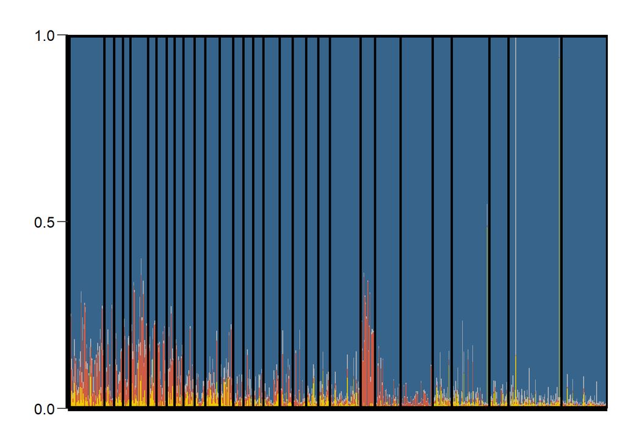

```r
ggplot(below, aes(fill = name, y = value, x = str_Ind)) +
  geom_bar(position = "stack", stat = "identity", width = 1) +
  scale_fill_manual(values = c("steelblue4", "grey70", "coral3", "gold2"), name = "Cluster") +
  geom_segment(aes(x = 0.5, xend = 792.5, y = 1.0, yend = 1.0), colour = 'black', linewidth = 2, inherit.aes = FALSE) +
  scale_x_discrete(expand = c(0.0, 0.0)) +
  scale_y_continuous(expand = c(0, 0), breaks = c(0.0, 0.5, 1.0)) +
  geom_line() +
  geom_vline(xintercept = vlines, linewidth = 1)+
  xlab("") +
  ylab("") +
  theme(panel.background = element_blank(),
        text = element_text(family = "sans"),
        legend.position = "none",
        plot.margin = margin(1, 0.5, 0.5, 0.5, "cm"),
        legend.title = element_text(size = 16),
        legend.text = element_text(size = 12),
        axis.line = element_line(size = 2, color = 'black'),
        axis.ticks.x = element_blank(),
        axis.ticks.length.y = unit(0.3, "cm"),
        axis.text.x = element_blank(),
        axis.text.y = element_text(size = 12, colour = 'black')
  )
```

Prepare STRUCTURE results for the Upper Klamath Lake and those watersheds upstream.

```r
##Subset locations upstream of Upper Klamath Lake
upper<-subset(all_basin, all_basin$watershed == "Upper Klamath Lake" | all_basin$watershed == "KLCT" | all_basin$watershed == "Wood River" | all_basin$watershed == "Williamson River" | all_basin$watershed == "Sprague River" | all_basin$watershed == "Great Basin" | all_basin$watershed == "Cape Cod Stock (72)" | all_basin$watershed == "Klamath Hatchery")

##New object so need to reset order of individuals within locations, locations within watersheds, and watersheds
upper$structure_number <- factor(upper$structure_number, levels = unique(upper$structure_number))
upper$str_Ind<-factor(upper$str_Ind, levels = unique(upper$str_Ind))
upper$watershed <- factor(upper$watershed, levels = unique(upper$watershed))

####Calculate vertical line placement for each location based on their sample size
df_segment_upper <- upper %>%
  group_by(structure_number) %>%
  summarise(n = sum(length(unique(Ind))))

##Add the sample size of the current location to the one before it with the cumulative sum (cumsum) command##
vlines<-cumsum(as.numeric(df_segment_upper$n))
```

Make the STRUCTURE plot for the Upper Klamath Lake and those watersheds upstream (Fig. 2c ; k = 4). Note, the plot created in this R markdown file is compressed. Export the plot to make it larger.

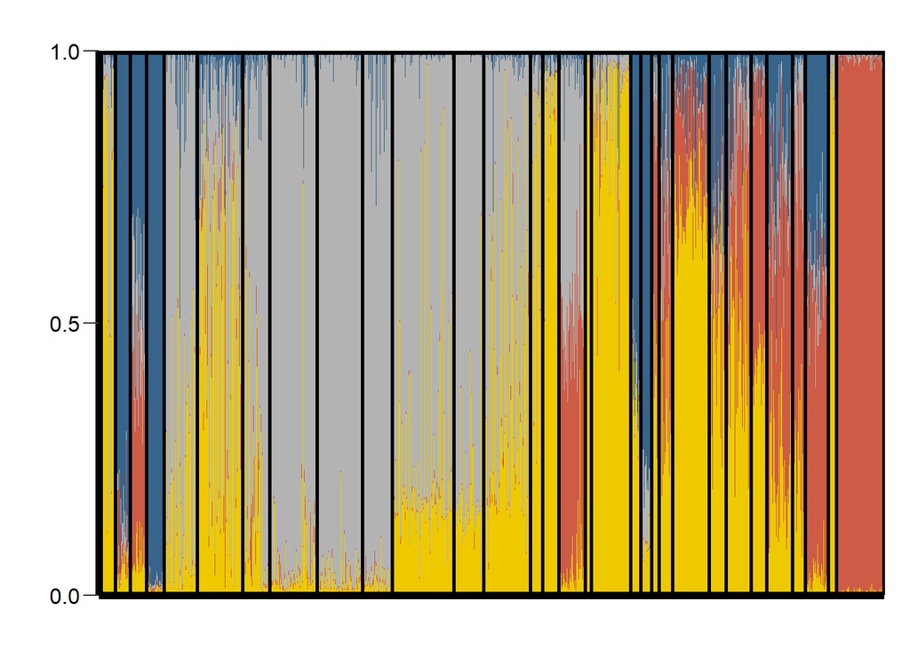

```r
ggplot(upper, aes(fill = name, y = value, x = str_Ind)) +
  geom_bar(position = "stack", stat = "identity", width = 1) +
  scale_fill_manual(values = c("steelblue4", "grey70", "coral3", "gold2"), name = "Cluster") +
  geom_segment(aes(x = 0.5, xend = 1289.5, y = 1.0, yend = 1.0), colour = 'black', linewidth = 2, inherit.aes = FALSE) +
  scale_x_discrete(expand = c(0.0, 0.0)) +
  scale_y_continuous(expand = c(0, 0), breaks = c(0.0, 0.5, 1.0)) +
  geom_line() +
  geom_vline(xintercept = vlines, linewidth = 1)+
  xlab("") +
  ylab("") +
  theme(panel.background = element_blank(),
        text = element_text(family = "sans"),
        legend.position = "none",
        plot.margin = margin(1, 0.5, 0.5, 0.5, "cm"),
        legend.title = element_text(size = 16),
        legend.text = element_text(size = 12),
        axis.line = element_line(size = 2, color = 'black'),
        axis.ticks.x = element_blank(),
        axis.ticks.length.y = unit(0.3, "cm"),
        axis.text.x = element_blank(),
        axis.text.y = element_text(size = 12, colour = 'black')
  )
```

In analyses with both k = 2 and k = 4 clusters, there was an apparent divide in the genetic composition of O. mykiss downstream and upstream of the Upper Klamath Lake. Downstream of the lake in the Trinity, Salmon, and Klamath rivers, O. mykiss were genetically similar. Upstream of Upper Klamath Lake, collections of O. mykiss were more genetically diverse, with some locations sharing the downstream genetic signature and others with a distinctive upstream composition.